# The statistical model behind SIAR (and simmr)

## Learning outcomes:

- Understand the statistical model behind SIAR
- Know how to run a model in SIAR and check that it works
- Be able to follow the technical details of the 2010 SIAR Plos ONE paper

## Our simple SIMM

- In the last class we had a simple SIMM defined via: \[ y_i \sim N\left(\sum_{k=1}^2 p_ks_k,\sigma^2\right)\] with \(s_k \sim N(\mu_{s_k},\sigma_{s_k}^2)\), \(p_1 \sim U(0,1)\) and \(\sigma \sim U(0,100)\)
- Here \(y_i\) is the isotope value, \(s\) are the source values, \(p\) are the dietary proportions, and \(\sigma\) is the residual standard deviation
- The goal is to estimate the \(p\) and its uncertainty. The other parameters can be considered nuisance parameters

## Expanding the simple SIMM

- This SIMM is currently too simplistic. We need to expand it by:
  - increasing the number of food sources
  - including trophic enrichment factors (TEFs)
  - including concentration dependence
  - allowing for multiple isotopes
  - allowing for richer source sampling by consumers
- If we include all of these factors we end up with the SIAR model
- We will take them in turn and add them into our JAGS code

## Reminder: the SIAR geese data

```r
data(geese1demo,sourcesdemo)
head(geese1demo,3)
```

```
##      d15NPl d13CPl
## [1,]  10.22 -11.36
## [2,]  10.37 -11.88
## [3,]  10.44 -10.60
```

```r
sourcesdemo
```

```
##        Sources  Meand15N    SDd15N  Meand13C    SDd13C
## 1      Zostera  6.488984 1.4594632 -11.17023 1.2149562
## 2        Grass  4.432160 2.2680709 -30.87984 0.6413182
## 3    U.lactuca 11.192613 1.1124385 -11.17090 1.9593306
## 4 Enteromorpha  9.816280 0.8271039 -14.05701 1.1724677
```

## Plotting the data

A plot in isotope space:

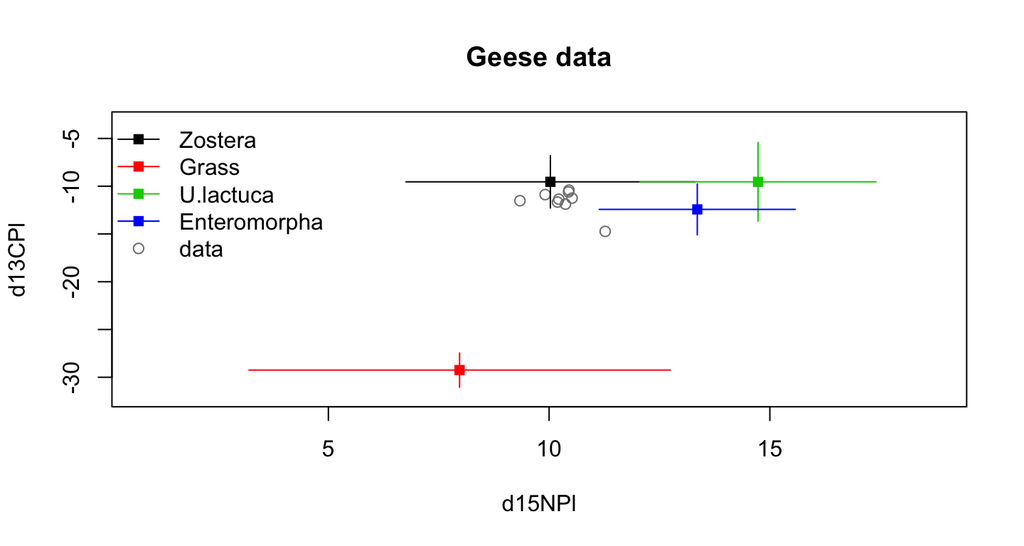

```r
data(correctionsdemo,concdepdemo)
out = siarmcmcdirichletv4(geese1demo,sourcesdemo,correctionsdemo,concdepdemo)
out$TITLE = 'Geese data'
siarplotdata(out)
```

## Including multiple sources

- Adding in multiple sources to the likelihood is straightforward: \[ y_i \sim N\left(\sum_{k=1}^K p_ks_k,\sigma^2\right)\]
- In the above we have \(K\) sources and hence \(K\) dietary proportions
- We also now need \(K\) source prior distributions
- The tricky part about adding in multiple proportions is the prior distribution

## JAGS SIMM with a Dirichlet prior

```r
modelstring ='
model {
  for(i in 1:N) { y[i] ~ dnorm(inprod(p,s),sigma^-2) }
  p ~ ddirch(alpha)
  for(k in 1:K) { s[k] ~ dnorm(s_mean[k],s_sd[k]^-2) }
  sigma ~ dunif(0,100)
}
'
sources = sourcesdemo[,4:5]
data=list(y=consumers,s_mean=sources[,1],s_sd=sources[,2],
          N=length(consumers),K=nrow(sources),
          alpha=rep(1,nrow(sources)))
model=jags.model(textConnection(modelstring), data=data)
output=coda.samples(model=model,variable.names=c("p"),n.iter=1000)
```

This is now running with all 4 sources

## Results

- We can explore/plot results with `summary(output)`, `plot(output)`, and also run multiple chains, form predictive distributions, check convergence, etc
- One important thing to note is that the fitting method (MCMC) produces a joint posterior distribution of the dietary proportions. This means that each set of samples will sum to 1:

```r
head(as.matrix(output[[1]]),2)
```

```
##           p[1]       p[2]      p[3]      p[4]
## [1,] 0.2540347 0.01891589 0.3390915 0.3879579
## [2,] 0.2540347 0.01891589 0.3390915 0.3879579
```

- The key implication of this is that, aside from exploring the *marginal* posterior distributions (with means, sds, etc) we can explore the *joint* uncertainty of the dietary proportions

## A joint plot of the posterior dietary proportions

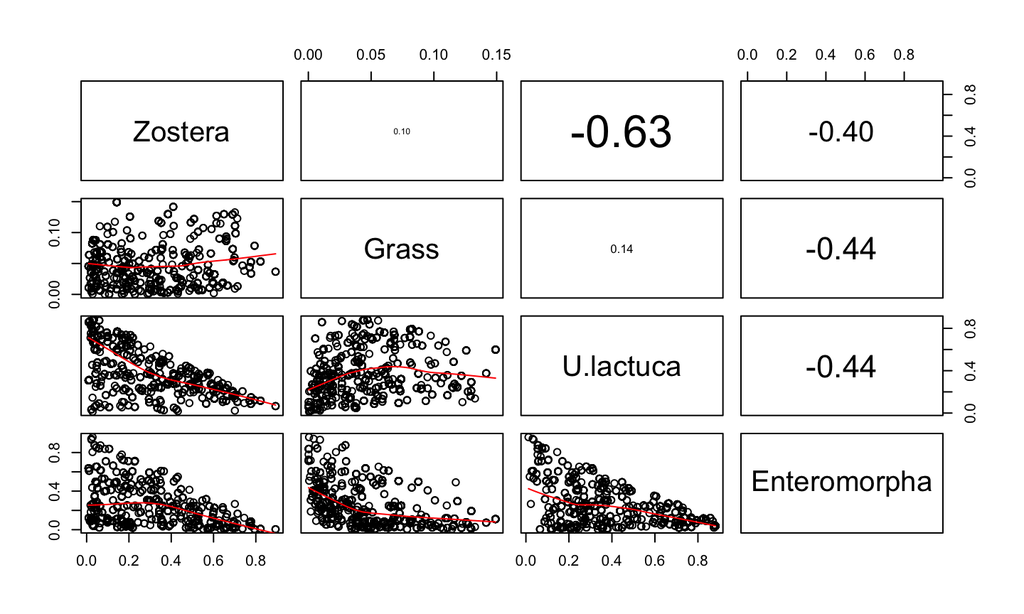

```r
out_2 = as.matrix(output[[1]])
colnames(out_2) = sourcesdemo[,1]
pairs(out_2, lower.panel = panel.smooth, upper.panel = panel.cor)
```

## Trophic enrichment factors and concentration dependence

- Trophic enrichment factors (\(c\)) and concentration dependence (\(q\)) represent adjustments to the source values to account for various measurement effects
- We can include them by expanding the likelihood: \[ y_i \sim N \left( \frac{\sum_{k=1}^K p_k q_k (s_k+c_k)}{\sum_{k=1}^K p_k q_k}, \sigma^2\right) \]
- The extra part on the denominator is needed so that the dietary proportions still sum to 1
- The prior for \(c_k\) comes from external data and are given normal distributions like the source values
- In SIAR the concentration dependencies must be less than 1 (given as proportions) and are treated as fixed. You could use a strong Dirichlet prior on these instead

## Including TEFs and CD - JAGS model

```r
modelstring ='
model {
  for(i in 1:N) {
    y[i] ~ dnorm(inprod(p*q,s+c)/inprod(p,q),sigma^-2)
  }
  p ~ ddirch(alpha)
  for(k in 1:K) {
    s[k] ~ dnorm(s_mean[k],s_sd[k]^-2)
    c[k] ~ dnorm(c_mean[k],c_sd[k]^-2)
  }
  sigma ~ dunif(0,100)
}
'
data(concdepdemo)
data(correctionsdemo)
data=list(y=consumers,s_mean=sources[,1],s_sd=sources[,2],
          c_mean=correctionsdemo[,4],c_sd=correctionsdemo[,5],
          q=concdepdemo[,4],N=length(consumers),K=nrow(sources),
          alpha=rep(1,nrow(sources)))
model=jags.model(textConnection(modelstring), data=data)
output=coda.samples(model=model,variable.names=c("p"),n.iter=10000)
```

## Notes on the TEF and CD model

- If you run this, you'll find that convergence isn't quite as neat and it starts to get a bit slower
- Although it's a nuisance parameter, saving `sigma` is often a good idea because a large value indicates a poorly fitting model (usually also seen in the iso-space plot)
- The model will also create posterior distributions for \(s\) and \(c\), though these are usually pretty similar to the prior, as there isn't much information about their values in the data

## Adding extra isotopes

- If we have extra isotopes we can just list the likelihood twice, once for each value of the isotope. Only the dietary proportions are 'shared' between the isotopes
- Now write \(y_{ij}\) as the consumer values for observation \(i\) on *isotope* \(j\), where \(j=1,\ldots,J\)
- We now have source values \(s_{jk}\), TEF values \(c_{jk}\), concentration dependencies \(q_{jk}\), and each isotope has its own residual standard deviation \(\sigma_j\)
- The likelihood is now: \[ y_{ij} \sim N \left( \frac{\sum_{k=1}^K p_k q_{jk} (s_{jk}+c_{jk})}{\sum_{k=1}^K p_k q_{jk}}, \sigma_j^2\right) \]

## Richer source sampling

- The model we've been fitting up to now assumes that all individuals sample the same source value \(s_k\) for each source and isotope. This is unrealistic
- A better model has each individual sampling a different source value from the source prior distribution, i.e. we now have \(s_{ik}\) (or \(s_{ikj}\) with multiple isotopes)
- The JAGS code becomes:

```r
for(k in 1:K) {
  for(i in 1:N) {
    s[i,k] ~ dnorm(s_mean[k],s_sd[k]^-2)
  }
}
```

## The full SIAR model

- Using the trick mentioned on the last slide, we end up with a full model which looks like this: \[ y_{ij} \sim N \left( \frac{\sum_{k=1}^K p_k q_{jk} (\mu_{s,jk}+\mu_{c,jk})}{\sum_{k=1}^K p_k q_{jk}}, \frac{\sum_{k=1}^K p_k^2 q_{jk}^2 (\sigma_{s,jk}^2+\sigma_{c,jk}^2)}{(\sum_{k=1}^K p_k q_{jk})^2} + \sigma_j^2\right) \]
- This model has a more complicated likelihood, but removes the extra \(s\) and \(c\) parameters

## Full SIAR model: JAGS code

```r
modelstring ='
model {
  for (i in 1:N) {
    for (j in 1:J) {
      y[i,j] ~ dnorm(inprod(p*q[,j], s_mean[,j]+c_mean[,j]) /
        inprod(p,q[,j]), var_y[j]^-1)
    }
  }
  p ~ ddirch(alpha)
  for(j in 1:J) {
    var_y[j] <- inprod(pow(p*q[,j],2),s_sd[,j]^2+c_sd[,j]^2)/pow(inprod(p,q[,j]),2)
      + pow(sigma[j],2)
  }
  for(j in 1:J) { sigma[j] ~ dunif(0,100) }
}
'
```

## Full SIAR model: R code

```r
sources = as.matrix(sourcesdemo[,2:5])
tefs = as.matrix(correctionsdemo[,2:5])
cd = as.matrix(concdepdemo[,c(2,4)])
data=list(y=geese1demo,s_mean=sources[,c(1,3)],s_sd=sources[,c(2,4)],
          c_mean=tefs[,c(1,3)],c_sd=tefs[,c(2,4)],
          q=cd,N=nrow(geese1demo),
          J=ncol(geese1demo),alpha=rep(1,nrow(sources)))
model=jags.model(textConnection(modelstring), data=data)
output=coda.samples(model=model,variable.names=c("p",'sigma'),n.iter=10000,nthin=10)
```

## Summary of posterior dietary proportions

```r
out_2 = as.matrix(output[[1]])
colnames(out_2) = c(as.character(sourcesdemo[,1]),'SD1','SD2')
t(round(apply(out_2,2,quantile,probs=c(0.025,0.5,0.975)),2))
```

```
##              2.5%  50% 97.5%
## Zostera      0.40 0.59  0.81
## Grass        0.02 0.07  0.12
## U.lactuca    0.00 0.12  0.33
## Enteromorpha 0.02 0.20  0.49
## SD1          0.02 0.38  1.51
## SD2          0.06 0.89  2.47
```

Some of these proportions are quite imprecise: perhaps see better with matrix plot?

## Running SIAR

- The SIAR R package runs exactly this model with a few extra tweaks
- It contains a slightly optimised algorithm as JAGS sometimes gets a bit stuck on harder data sets. It's also much faster than JAGS for complicated problems
- It allows for direct plotting of the data in isotope space and \(p\)-space (i.e. dietary proportion space - `pairs` plots)
- It allows for changing the \(\alpha\) values to put in proper prior information
- It includes convergence checking
- Most of this covered in the practical this afternoon

## Running SIAR 2

- Running SIAR is as simple as giving it the relevant parts:

```r
out = siarmcmcdirichletv4(geese1demo,sourcesdemo,correctionsdemo,concdepdemo)
```

```r
out_2 = out$output
colnames(out_2) = c(as.character(sourcesdemo[,1]),'SD1','SD2')
t(round(apply(out_2,2,quantile,probs=c(0.025,0.5,0.975)),2))
```

```
##              2.5%  50% 97.5%
## Zostera      0.40 0.56  0.77
## Grass        0.03 0.07  0.12
## U.lactuca    0.01 0.12  0.35
## Enteromorpha 0.01 0.22  0.49
## SD1          0.02 0.37  1.48
## SD2          0.07 0.90  2.42
```

- Most people get stuck using SIAR just getting their data into the right format

## Matrix plot of dietary proportions

```
## Matrix plot of groups proportions.
## Producing plot.....
##
```

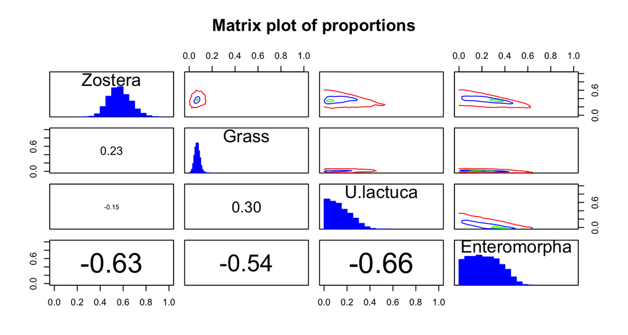

```r
siarmatrixplot(out)
```

## Summary

- The SIAR model is just a complicated regression-type model
- The response is multivariate and the prior distributions on some of the parameters have to be constrained to sum to 1
- It used to be the case that JAGS was slow and couldn't run SIMM-type models. This is no longer true. You can fit much richer models in JAGS (and now MixSIAR) than with SIAR
- More details on running SIAR in the practical this afternoon